# Transformer l’évaluation des étudiants en science des données biologiques grâce à des tutoriels interactifs

Guyliann Engels

guyliann.engels@umons.ac.be

Philippe Grosjean

philippe.grosjean@umons.ac.be

## Qui sommes-nous ?

### Philippe Grosjean

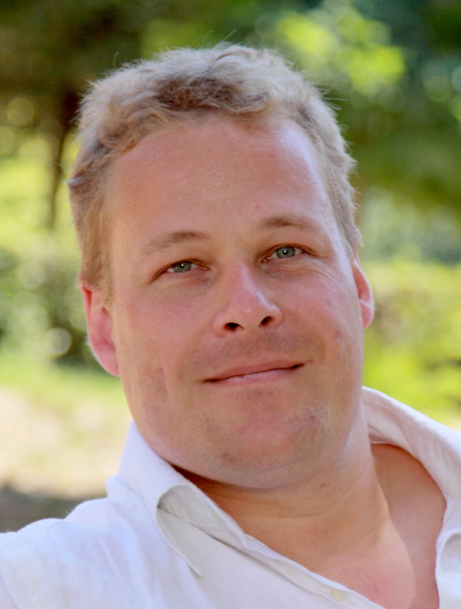

- Professeur
- Biologiste marin
- Développeur en R

### Guyliann Engels

[figure not shown]

- Adjoint pédagogique
- Biologiste marin
- Utilisateur de R

## Les cours de science des données dans le cursus en biologie

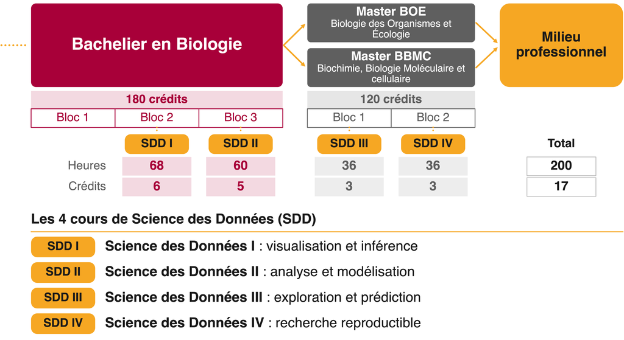

## Science des données biologiques à l’Université de Mons

On veut des étudiants **actifs**

**Cours classique *ex cathedra* + séances d’exercices**

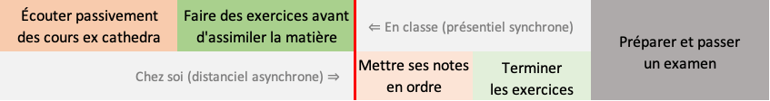

**Approche en classe inversée**

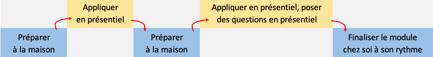

## Enseigner la science des données biologiques

Ce cursus vise à donner une série de compétences englobant des notions de biologie, de statistique et de programmation afin de **répondre à une question biologique.**

[figure not shown]

## Évaluer les apprentissages en science des données

Le grand défi est de proposer une **évaluation** en accord avec les **objectifs d’apprentissage** et les **activités d’enseignement**.

**Statistique & biologie** : évaluation via des projets, des QCM, des questions ouvertes…

**Programmation**

- Projets : les étudiants peuvent s’entraider ou utiliser l’IA
- Examen papier : écrire du code R sur papier est artificiel et frustrant

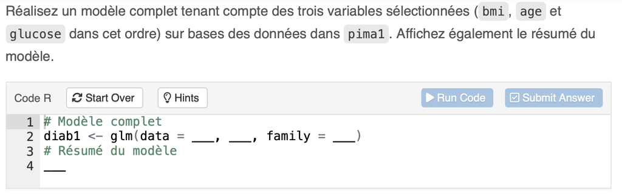

## learnr comme bon candidat

Une interrogation sur **ordinateur**, via un **outil connu**, avec des questions variées

| Type | Exemple | Ce qu’on évalue |
| --- | --- | --- |
| QCM | Interpréter un tableau résumé de modèle | Compréhension conceptuelle |
| Question ouverte | Définir la déviance des résidus | Capacité d’explication |
| Codage en R | Ajuster un GLM, comparer deux modèles | Compétence pratique réelle |

Un learnr par défaut ne permet pas d’**enregistrer les résultats**, ni de s’exécuter dans un **environnement contrôlé**.

## Adaptation du learnr pour l’évaluation

[figure not shown]

## Passation du test par l’étudiant

[figure not shown]

[figure not shown]

## Sécurisation à deux niveaux

### Côté client — [Safe Exam Browser](https://safeexambrowser.org/news_en.html)

- Fichier *.seb* distribué aux étudiants avant l’épreuve
- Mode kiosque : accès restreint aux pages autorisées (learnr + site de cours)

### Côté serveur — AppArmor

- Profil restreint pour le processus R
- Accès limité aux packages R nécessaires et au système d’exploitation Linux

Deux couches indépendantes : sécurité robuste sans sacrifier l’interactivité.

## Correction de l’enseignant : {learnitgrid}

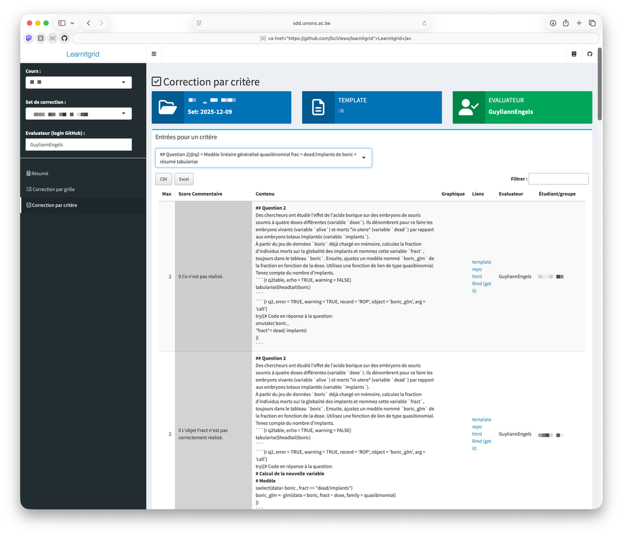

## Correction assistée : longueur du feedback

### → Le LLM rédige un feedback plus long, même pour les réponses correctes

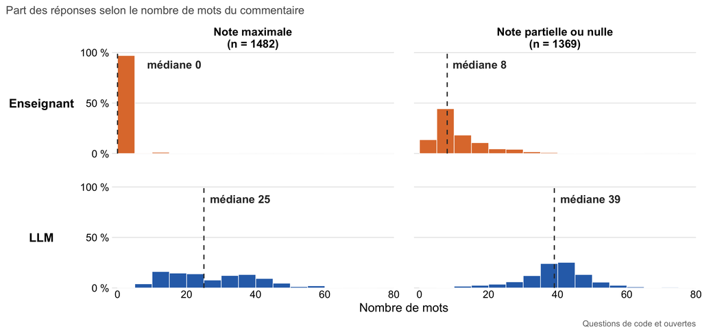

## Correction assistée : accord avec la note de l’enseignant

### → Désaccord important : l’enseignant reste garant de la note

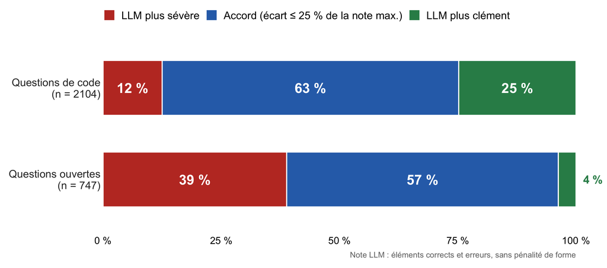

## Correctif issu du même Rmd que le learnr

Un [seul fichier R Markdown](https://github.com/BioDataScience-Course/sdd_presentations/blob/master/2026_rencontresr_nantes/learnr_exam/exam_example.Rmd) avec des balises spéciales pour le questionnaire interactif ({learnr}) et pour le corrigé (fichier HTML).

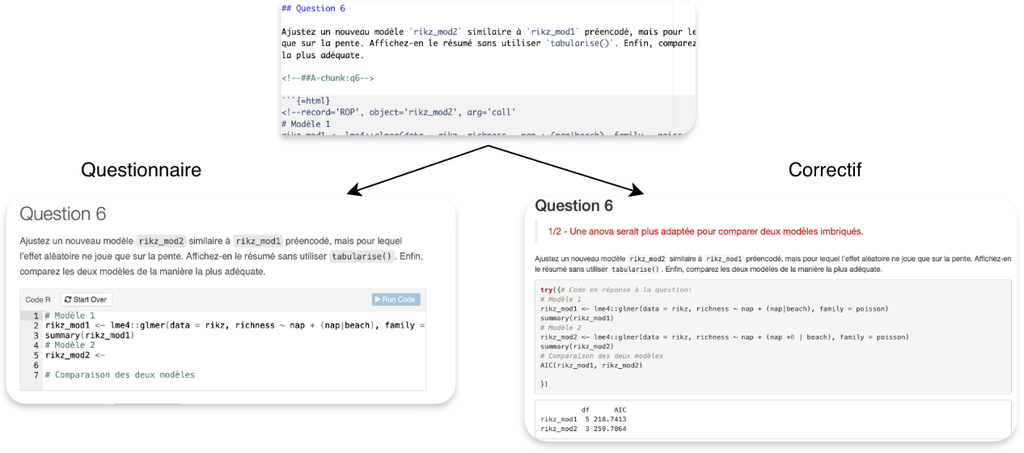

## Rapport de correction de l’étudiant

### Exemple anonymisé d’un correctif en HTML

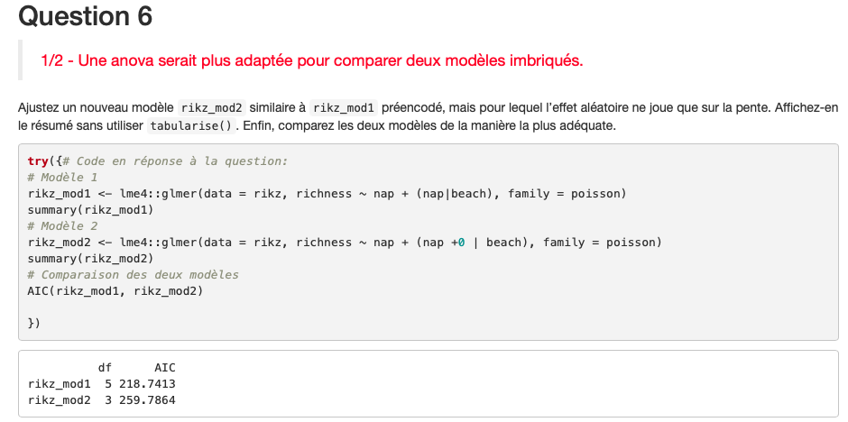

## Ce que les données révèlent : maîtrise du langage

### → Amélioration dans l’écriture du code

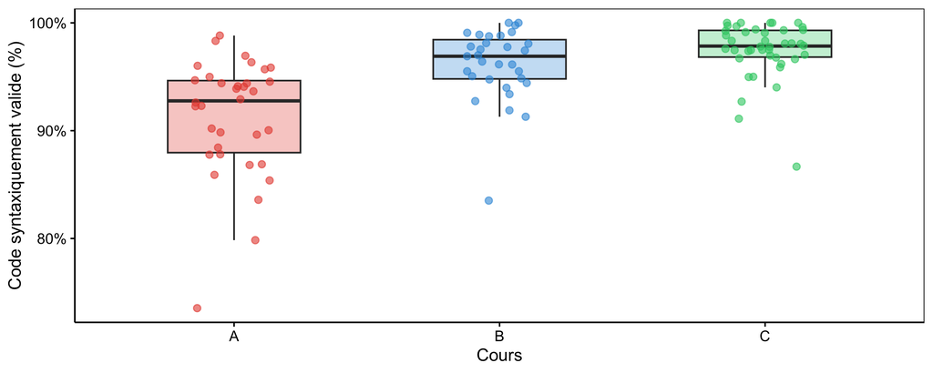

## Ce que les données révèlent : tentatives & résultats

### → Augmentation de la complexité des questions

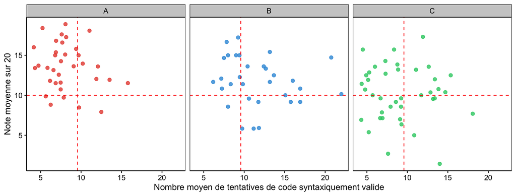

## Conclusions

1. **Source unique** : épreuve + corrigé depuis un seul fichier
2. Données du learnr enregistrées dans une **base de données** (MongoDB)
3. **Double sécurisation** (Safe Exam Browser + AppArmor)
4. **Grilles de correction** pour chaque question (learnitgrid)
5. **Bonus** : données exploitables pour mesurer la progression des étudiants

**À suivre** : *Enseignement des statistiques avec R et learnitr : approche explicite en mode hybride et évaluation continue* (Philippe Grosjean)

**Liens utiles**

- Matériel exemple : https://go.sciviews.org/learnr_exam
- learnitr : https://learnitr.r-universe.dev
  - **learnitdown** : enregistrement learnr dans la base de données
  - **learnitgrid** : interface de correction
  - **learnitprogress** : rapport de correction pour l’étudiant (HTML)
  - **learnitexam** : futur package si intérêt de la communauté
- Contact : sdd@sciviews.org